# Introduction to Topic Modelling

Alena Suvorova

25 04 2017

### Тематическое моделирование

Имеется коллекция документов. Хотим обнаружить «темы», из которых она сформирована.

LDA (Latent Dirichlet Allocation):

- Каждый документ представляет собой смесь тем.
- «Тема» — набор слов, которые могут с разными вероятностями употребляться при обсуждении данной темы.

Соответственно, у каждого документа в коллекции — свое распределение тем (в одном документе представлены только некоторые темы коллекции).

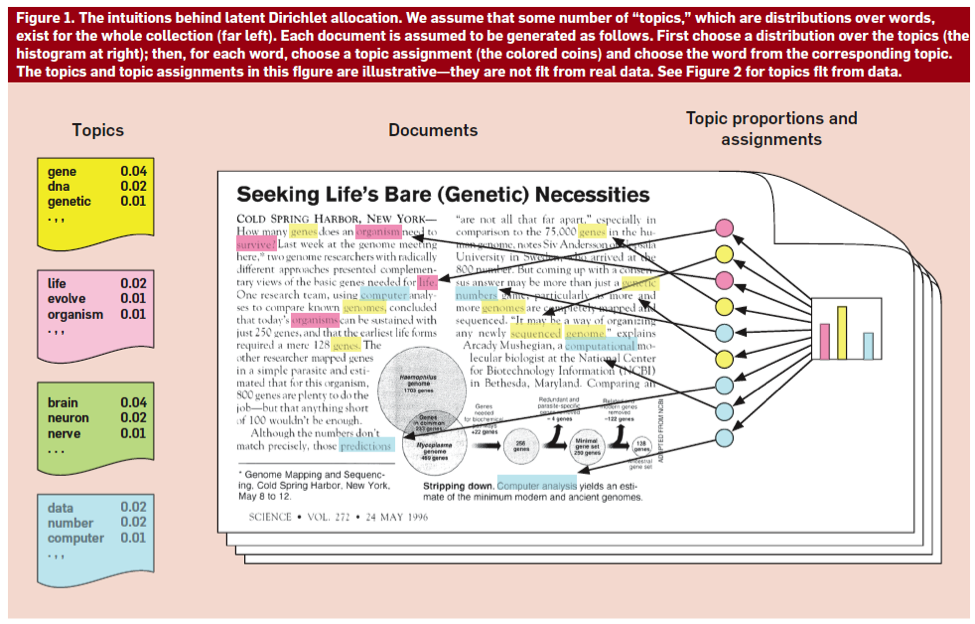

Больше информации о тематическом моделировании:

- [Topic modelling in Text Mining with R](http://tidytextmining.com/topicmodeling.html)
- [topicmodels package](https://cran.r-project.org/web/packages/topicmodels/vignettes/topicmodels.pdf)

### Загрузка данных

Работаем с данными Amazon о фильмах

```r
library(jsonlite)
library(stringr)
library(dplyr)
```

Чтение и преобразование данных

```r
j = readLines("~/shared/minor2_2016/data/amazon/reviews_Movies_and_TV_5_sub48.json") %>%
  str_c(collapse = ",") %>%
  (function(str) str_c("[", str, "]")) %>%
  fromJSON(simplifyDataFrame = T)

jmeta = readLines("~/shared/minor2_2016/data/amazon/meta_Movies_and_TV_5_sub48.json") %>%
  str_c(collapse = ",") %>%
  (function(str) str_c("[", str, "]")) %>%
  fromJSON(simplifyDataFrame = T)
```

Возьмем из мета-информации только заголовки и уберем комментарии в скобках

```r
jmeta = select(jmeta, title, asin)
jmeta$title = str_replace_all(jmeta$title, "\\(.*\\)", "")
jmeta$title = str_replace_all(jmeta$title, "\\[.*\\]", "")
```

Присоединим заголовки к основному датасету

```r
j = left_join(j, jmeta, by = "asin")
```

Удалим не нужные сегодня переменные

```r
j = select(j, asin, reviewText, overall, title)
```

Посчитаем, сколько отзывов написано на каждый из фильмов в нашей выборке. Оставим только те фильмы, где есть 35+ отзывов

```r
counts = j %>% group_by(asin) %>% summarize(n = n()) %>% arrange(-n)
counts
```

```
## # A tibble: 500 × 2
##          asin     n
##         <chr> <int>
## 1  B00005JPY0    51
## 2  B00005JNTI    42
## 3  B00005JPTK    42
## 4  B000M341QE    42
## 5  B00005JN2Z    41
## 6  B00005JPS8    40
## 7  0788860704    39
## 8  B000J10EQU    38
## 9  B00005JN0T    37
## 10 0790745399    36
## # ... with 490 more rows
```

```r
j = inner_join(j, counts, by = "asin") %>% filter(n >=35)
```

Посмотрим, что это за фильмы

```r
unique(select(j, title, n))
```

```
##                                                              title  n
## 1   The Chronicles of Narnia: The Lion, the Witch and the Wardrobe 39
## 40                                                      The Matrix 36
## 76                                                       I, Robot  37
## 113                                                    Collateral  41
## 154                                              War of the Worlds 42
## 196                    Pirates of the Caribbean: Dead Man's Chest  36
## 232                                                      Iron Man  40
## 272                                                   I Am Legend  42
## 314                                               The Dark Knight  51
## 365                                              Superman Returns  38
## 403                                                  The Prestige  35
## 438                                                  The Departed  42
```

### Работа с текстом

Начинаем работать с текстом: удаляем цифры, пунктуацию, разбиваем на слова, удаляем стоп-слова, считаем частоты слов в тексте

```r
library(quanteda)
docs = corpus(j$reviewText)

textdfm = quanteda::dfm(docs, what="word",
              tolower = TRUE,
              removeNumbers = TRUE, removePunct = TRUE,
              remove = c(stopwords(kind = "english"), "film", "movie"))

# textdfm = quanteda::dfm(docs, what="word",
#               toLower = TRUE,
#               removeNumbers = TRUE, removePunct = TRUE,
#               ignoredFeatures = c(stopwords(kind = "english"), "film", "movie"))

dfmforTopics = convert(textdfm, to = "topicmodels")
```

### Построение модели

Построим модель с двумя темами

```r
library(topicmodels)
review2_lda <- LDA(dfmforTopics, k = 2, control = list(seed = 12345))
review2_lda
```

```
## A LDA_VEM topic model with 2 topics.
```

### Тема как смесь слов

Посмотрим на самые популярные слова в каждой теме. Для этого нам нужно сначала получить вероятности того, что слово относится к той или иной теме (per-topic-per-word probabilities), обозначаемые $\beta$ (*beta*)

```r
library(tidytext)
amazon2_topics <- tidy(review2_lda, matrix = "beta")
amazon2_topics
```

```
## # A tibble: 25,358 × 3
##    topic       term         beta
##    <int>      <chr>        <dbl>
## 1      1 chronicles 3.125745e-08
## 2      2 chronicles 6.335925e-04
## 3      1     narnia 3.328221e-06
## 4      2     narnia 2.669043e-03
## 5      1       lion 1.063038e-04
## 6      2       lion 1.165309e-03
## 7      1      witch 1.193674e-06
## 8      2      witch 1.651784e-03
## 9      1   wardrobe 7.209239e-05
## 10     2   wardrobe 1.308310e-03
## # ... with 25,348 more rows
```

Посмотрим на популярные слова в каждой теме

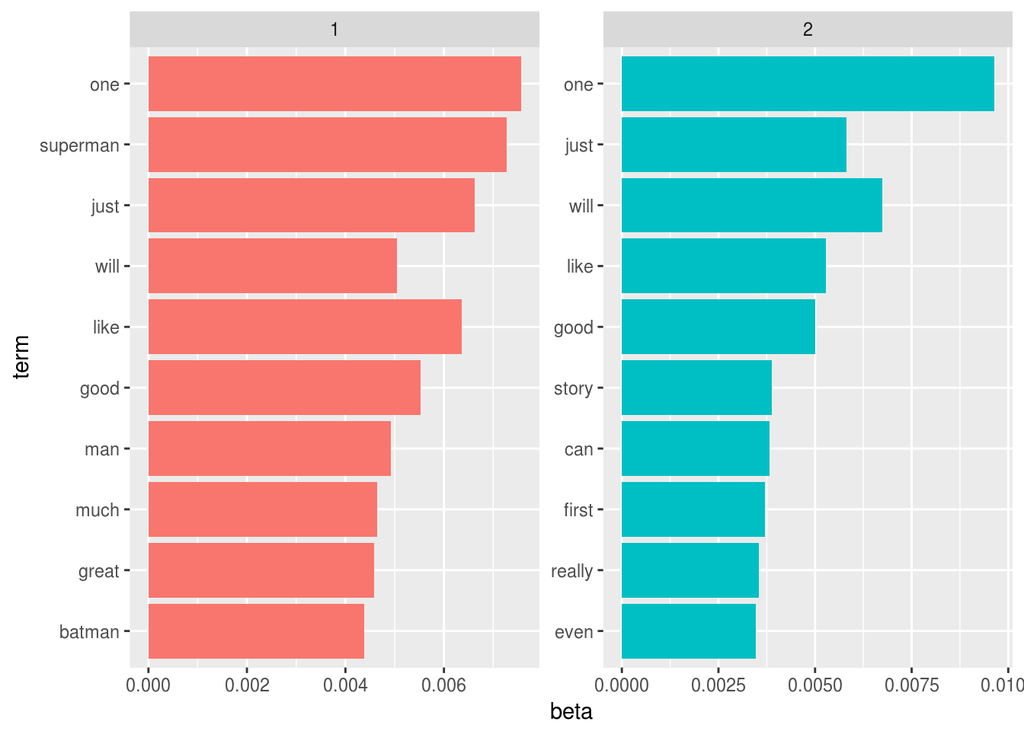

```r
library(ggplot2)

amazon2_top_terms <- amazon2_topics %>%
  group_by(topic) %>%
  top_n(10, beta) %>%
  ungroup() %>%
  arrange(topic, -beta)

amazon2_top_terms %>%
  mutate(term = reorder(term, beta)) %>%
  ggplot(aes(term, beta, fill = factor(topic))) +
  geom_col(show.legend = FALSE) +
  facet_wrap(~ topic, scales = "free") +
  coord_flip()
```

К сожалению, по такому набору сложно сказать, чем темы отличаются друг от друга, есть слова, которые встречаются в каждой из тем. Для сравнения тем между собой можно вычислять, насколько встречаемость слов различна между темами. Для этого используют логарифм отношения вероятностей $log_{2}(\beta_{1}/\beta_{2})$ (если $\beta_{1}$ в два раза больше, то это значение равно 1, если наоборот, то -1).

```r
library(tidyr)

beta_spread <- amazon2_topics %>%
  mutate(topic = paste0("topic", topic)) %>%
  spread(topic, beta) %>%
  filter(topic1 > .001 | topic2 > .001) %>%
  mutate(log_ratio = log2(topic1 / topic2)) %>%
  arrange(-log_ratio)

head(beta_spread)
```

```
## # A tibble: 6 × 4
##         term      topic1       topic2 log_ratio
##        <chr>       <dbl>        <dbl>     <dbl>
## 1      routh 0.001120439 2.577266e-29  85.16835
## 2       lane 0.001120439 3.052304e-28  81.60237
## 3 collateral 0.001177897 1.290487e-24  69.62879
## 4       lois 0.002671816 1.225377e-23  67.56316
## 5        max 0.002039774 4.188679e-23  65.40048
## 6    vincent 0.002327066 1.300914e-21  60.63369
```

Визуализируем. Что можно сказать про эти темы?

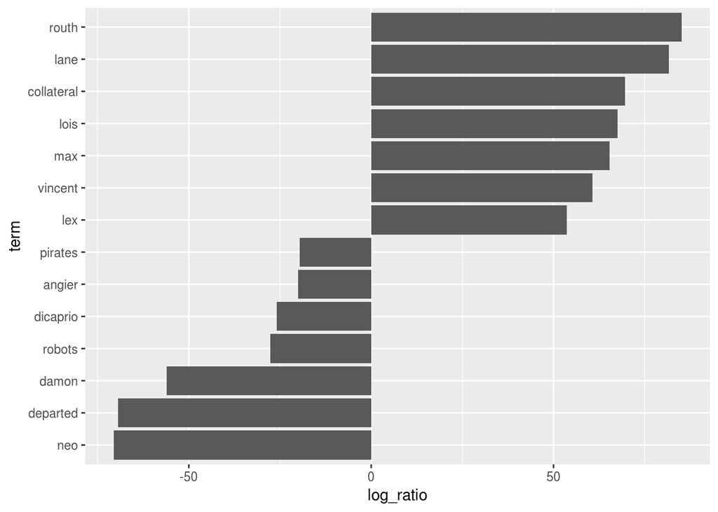

```r
dataDiff = rbind(head(beta_spread, 7), tail(beta_spread,7))

dataDiff %>%
  mutate(term = reorder(term, log_ratio)) %>%
  ggplot(aes(x = term, y = log_ratio)) +
  geom_col() +
  coord_flip()
```

### Документы как смесь тем

Посмотрим, как темы распределяются по отзывам. Получим вероятности того, что документ относится к той или иной теме (per-document-per-topic probabilities), обозначаемые $\gamma$ (*gamma*)

```r
amazon2_documents <- tidy(review2_lda, matrix = "gamma")
amazon2_documents
```

```
## # A tibble: 958 × 3
##    document topic        gamma
##       <chr> <int>        <dbl>
## 1     text1     1 0.3331326384
## 2     text2     1 0.9988794040
## 3     text3     1 0.0004198046
## 4     text4     1 0.0001939509
## 5     text5     1 0.0003473887
## 6     text6     1 0.3835224964
## 7     text7     1 0.0001552759
## 8     text8     1 0.0002392374
## 9     text9     1 0.9935940398
## 10   text10     1 0.5456443454
## # ... with 948 more rows
```

text1, text2, … – это отзывы в том порядке, в каком они были при создании матрицы частот. Т.к. мы в первоначальном датасете с тех пор ничего не меняли, то для удобства и сопоставления добавим еще один столбец и объединим

```r
j$document = paste0("text", rownames(j))
amazon2_documents  = left_join(amazon2_documents, j, by = "document")
```

Например, отзыв 400

```r
filter(amazon2_documents, document == "text400") %>% select(title, document, topic, gamma)
```

```
## # A tibble: 2 × 4
##               title document topic        gamma
##               <chr>    <chr> <int>        <dbl>
## 1 Superman Returns   text400     1 9.999054e-01
## 2 Superman Returns   text400     2 9.463666e-05
```

Распределение отзывов по темам

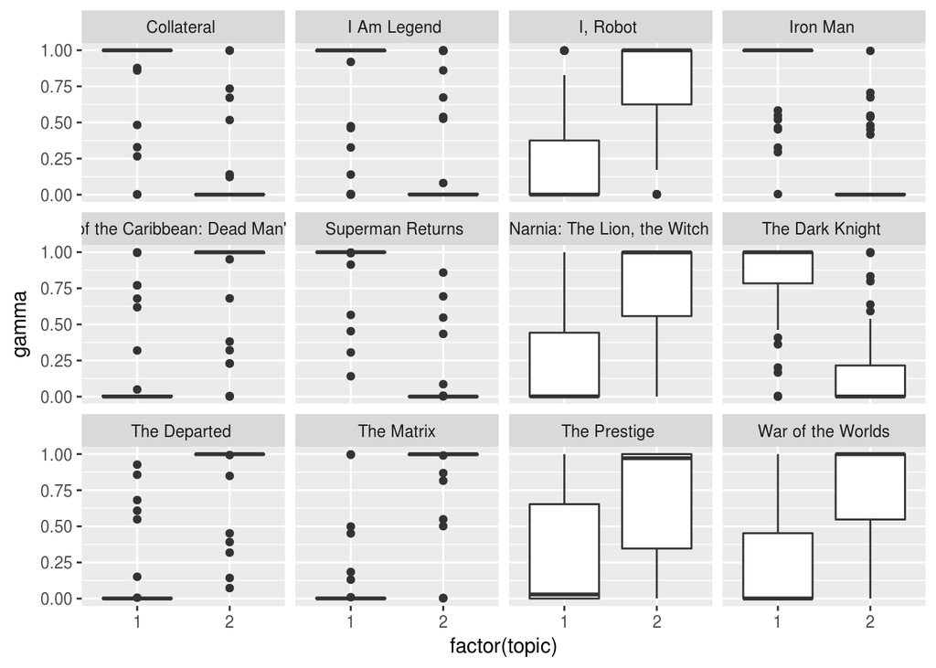

```r
ggplot(data = amazon2_documents, aes(x = factor(topic), y = gamma)) +
  geom_boxplot() +
  facet_wrap(~ title)
```

**Ваша очередь:**

Скорее всего для такого разнообразия текстов двух тем мало. Попробуйте выделить 5-7 тем. Как происходит разделение в этом случае?

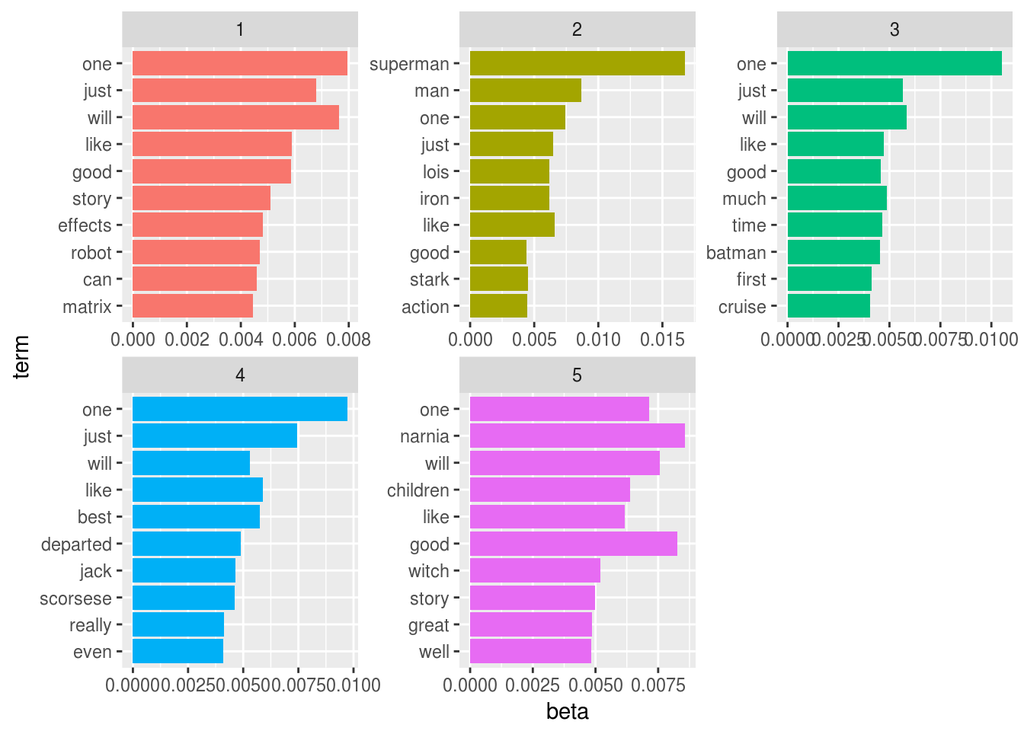

```r
review5_lda <- LDA(dfmforTopics, k = 5, control = list(seed = 1234))

amazon5_topics <- tidy(review5_lda, matrix = "beta")

amazon5_top_terms <- amazon5_topics %>%
  group_by(topic) %>%
  top_n(10, beta) %>%
  ungroup() %>%
  arrange(topic, -beta)

amazon5_top_terms %>%
  mutate(term = reorder(term, beta)) %>%
  ggplot(aes(term, beta, fill = factor(topic))) +
  geom_col(show.legend = FALSE) +
  facet_wrap(~ topic, scales = "free") +
  coord_flip()
```